# FMT Comms Report

Paul Hegedus

2022-07-05

# Introduction

The main questions addressed are;

- When is the best day and time to post?
- Do graphics or photos have higher engagement?
- Does too many emails or posts reduce open or engagement rates?

# Email

Report about email communications from Forward Montana (FMT). The summary and conclusion are short summaries of conclusions related to the following questions. The section for each question contains figures and more detailed interpretation.

## Summary

Analysis below is for addressing the following questions about email communications;

1. What day of the week and time of day have the highest open rates, when accounting for recipients?
2. What combination of day and time had highest open rates, when accounting for recipients?
3. How does frequency of emails in a week influence open rate?

The answers were;

1. When accounting for recipients, Thursday is the best day to send emails with an expected open rate of 18-19% and 5PM is the best hour of day to send emails with an expected open rate of 25%. Sending emails before 1PM decreases open rates
2. When accounting for recipients, Thursday at 5PM has the highest open rate. Thursday between 1PM and 5PM also had high open rates, as well as Friday at 5PM, and Wednesday at 4PM.
3. Sending more emails in a month, week, and day all lower average open rates. The frequency of emails per month, week, and day follow with the corresponding open rate. The average open rate was 25% when 6 emails were sent per month, the average open rate was 24% when 2 emails were sent per week, and the average open rate was 18% when 1 email were sent per day.

Quick statistics on email data;

Summary statistics of FMT email communications.

| Metric | Value | Rounded |
| --- | --- | --- |
| Average Open Rate | 18.55 | 19 |
| Average Recipients | 2727.40 | 2727 |
| Average Emails Sent per Month | 15.09 | 15 |
| Average Emails Sent per Week | 5.42 | 5 |
| Average Emails Sent per Day | 1.54 | 2 |

Before beginning analysis, insights about the email data from the exploratory phase showed two outliers that influence models and conclusions. The two highest emails with open rates, not accounting for recipients, were the “Progressive happy hour”, and the “School board forum reminder” with 5 and 46 recipients, respectively. These were deemed outliers and removed from the analysis below.

Outlier data points from email data, defined as open rate greater than 40%.

|  | Weekday | Date | Time | Email | Recipients | Open Rate (%) |
| --- | --- | --- | --- | --- | --- | --- |
| 15 | Thursday | 03/10/2022 | 09:01 AM | Progressive happy hour | 5 | 80.00 |
| 28 | Tuesday | 04/12/2022 | 10:00 AM | School board forum reminder | 46 | 46.45 |

## Question 1

What day of the week and time of day have the highest open rates, when accounting for recipients?

### Day of Week

The figures below illustrate the relationship between open rate (raw and adjusted, note y axis label), across weekdays. The bars indicate the 95% CI around the mean. This means that if we repeated collecting email data, we would expect the true mean open rate of emails would fall within this range 95% of samples. Further Interpretation of open rate and adjusted open rate’s relationship with weekday is below.

#### Raw Open Rate

The figures and analysis below use the original open rate percent as the metric. Recipients are accounted for in the statistical analysis.

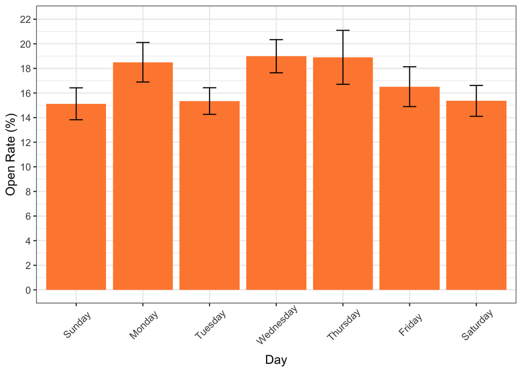

The mean open rate percent for emails sent on Sunday, Tuesday, Friday, and Saturday are lower than for Monday, Wednesday, or Thursday. Based on the raw open rate data, there appears to be no difference between open rates for emails sent on Monday, Wednesday, or Thursday. The following paragraphs outline the results from statistical tests for whether there is a difference between open rates across days of the week.

The best linear regression model that characterizes open rates utilizes the number of recipients, the number of emails sent that day, and the month of year as parameters. Testing of different models found that these were the only statistically significant variables that affect open rate percent.

However to assess the influence of day of week on open rate it has to be added to the model, despite no statistical basis. When we account for all of the other variables in the model (recipients, frequency, etc.), there is no statistical evidence that the day of the week an email is sent influences open rate.

```
## Anova Table (Type II tests)
##
## Response: open_rate_pct
##            Sum Sq Df F value    Pr(>F)
## Recipients 176.41  1  9.0259  0.004152 **
## day_freq   193.00  1  9.8749  0.002815 **
## month_f    991.03  5 10.1412 9.557e-07 ***
## weekday_f  217.68  6  1.8563  0.107102
## Residuals  977.23 50
## ---
## Signif. codes:  0 '***' 0.001 '**' 0.01 '*' 0.05 '.' 0.1 ' ' 1
```

These results indicate that there was no statistical evidence that open rate percent was affected by the day of the week. However, because the data collected is a census, thus representing all of the emails sent, we are not dealing with a sample and can make conclusions based on statistics easier to calculate, such as the mean.

The average open rate was 18-19% on Monday, Wednesday, and Thursday. It was only 15-16% on all other days. This means that emails sent on Monday, Wednesday, and Thursday are the best days, on average, to send an email with a high open rate.

#### Adjusted Open Rate

However, now we’ll look at the alternative metric. Adjusted open rate is a weighted open rate proportional to the number of recipients. It tells a slightly different story.

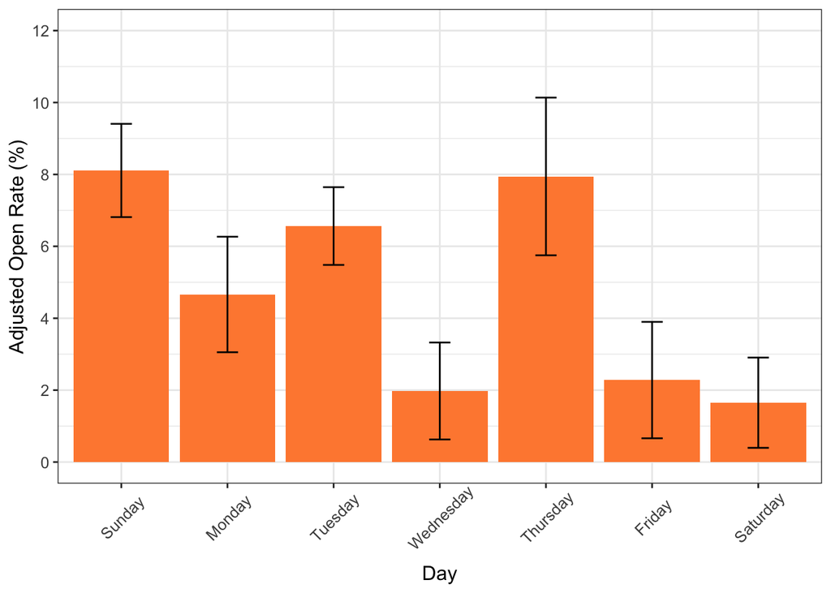

The mean adjusted open rate percent for emails sent on Sunday, Tuesday, Thursday are the greatest. The lowest open rates, adjusted by recipients, were on Wednesday, Friday, and Saturday.

The best linear regression model that characterizes adjusted open rates didn’t include recipients becauase it would be redundant. The statistically significant parameters were the interaction between month and weekday and the frequency of emails on a weekly basis. Testing of different models found that these were the only statistically significant variables that affect open rate percent.

```
## Global model call: lm(formula = open_rate_adj ~ month_f * weekday_f * hour_f + month_freq +
##     week_freq + day_freq, data = temp1)
## ---
## Model selection table
##     (Int) mnt_f wek_frq wkd_f mnt_f:wkd_f    R^2 df   logLik AICc delta weight
## 309 6.521     + -0.3612     +           + 0.9592 35 -114.498  389     0    0.5
## 317 6.521     + -0.3612     +           + 0.9592 35 -114.498  389     0    0.5
## Models ranked by AICc(x)
```

```
## Anova Table (Type II tests)
##
## Response: open_rate_adj
##                    Sum Sq Df F value    Pr(>F)
## month_f            486.93  5  21.776 3.651e-09 ***
## weekday_f          454.45  6  16.936 1.959e-08 ***
## week_freq           63.53  1  14.204 0.0007176 ***
## month_f:weekday_f 1801.23 21  19.179 4.517e-12 ***
## Residuals          134.17 30
## ---
## Signif. codes:  0 '***' 0.001 '**' 0.01 '*' 0.05 '.' 0.1 ' ' 1
```

#### Conclusion

Thursday is the best day to send emails with an expected open rate of 18-19%.

### Hour of Day

The figures below illustrate the relationship between open rate (raw and adjusted, note y axis label), across hour of day. Hour of day is the hour the email was sent, where if an email was sent at 12:37 PM the hour of day would be 12 PM. Note that axis text is in chronological order from left to right.

The bars indicate the 95% CI around the mean. This means that if we repeated collecting email data, we would expect the true mean open rate of emails would fall within this range 95% of samples. Further Interpretation of open rate and adjusted open rate’s relationship with hour of day is below.

#### Raw Open Rate

The figures and analysis below use the original open rate percent as the metric. Recipients are accounted for in the statistical analysis.

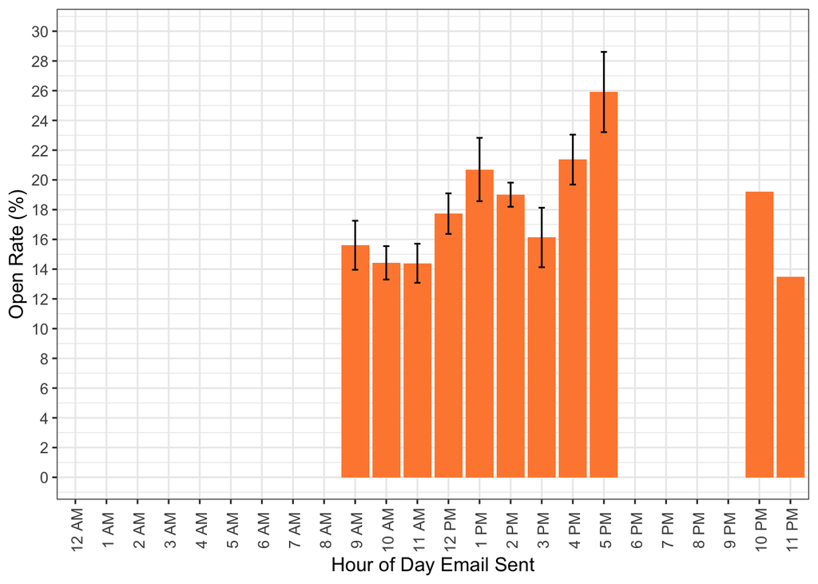

The mean open rate percent was highest when emails were sent at 5PM. Sending emails before 1PM decreased open rates.

The best linear regression model that characterizes open rates utilizes the number of recipients, the number of emails sent that day, and the month of year as parameters. Testing of different models found that these were the only statistically significant variables that affect open rate percent.

However to assess the influence of day of hour on open rate it has to be added to the model, despite no statistical basis. When we account for all of the other variables in the model (recipients, frequency, etc.), there is no statistical evidence that the hour of day an email is sent influences open rate.

```
## Anova Table (Type II tests)
##
## Response: open_rate_pct
##            Sum Sq Df F value    Pr(>F)
## Recipients 169.83  1  8.1242  0.006516 **
## day_freq    75.84  1  3.6278  0.063086 .
## month_f    772.26  5  7.3884 3.728e-05 ***
## hour_f     233.29 10  1.1160  0.371132
## Residuals  961.62 46
## ---
## Signif. codes:  0 '***' 0.001 '**' 0.01 '*' 0.05 '.' 0.1 ' ' 1
```

These results indicate that there was no statistical evidence that open rate percent was affected by the hour of day sent. However, because the data collected is a census, thus representing all of the emails sent, we are not dealing with a sample and can make conclusions based on statistics easier to calculate, such as the mean.

#### Adjusted Open Rate

However, now we’ll look at the alternative metric. Adjusted open rate is a weighted open rate proportional to the number of recipients. It tells a slightly different story.

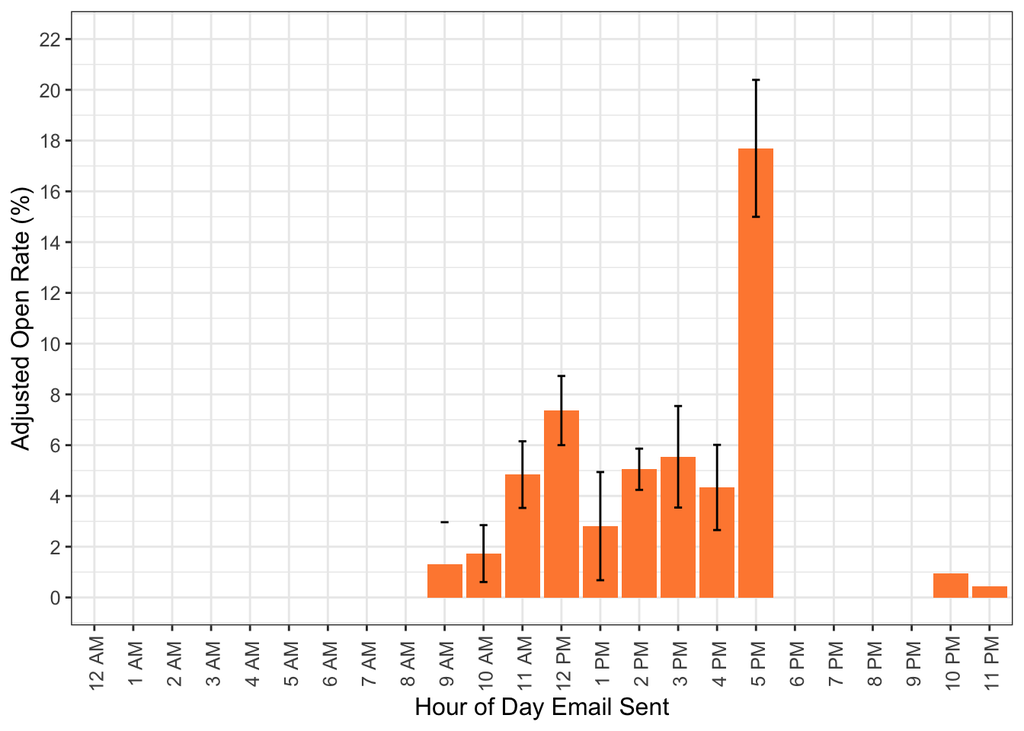

The mean adjusted open rate percent for emails sent at 5PM was the highest. Sending emails before 12PM remained ineffective at achieving high open rates.

The best linear regression model that characterizes adjusted open rates didn’t include recipients becauase it would be redundant. The statistically significant parameters were the interaction between month and weekday and the frequency of emails on a weekly basis. Testing of different models found that these were the only statistically significant variables that affect open rate percent.

```
## Global model call: lm(formula = open_rate_adj ~ month_f * weekday_f * hour_f + month_freq +
##     week_freq + day_freq, data = temp1)
## ---
## Model selection table
##     (Int) mnt_f wek_frq wkd_f mnt_f:wkd_f    R^2 df   logLik AICc delta weight
## 309 6.521     + -0.3612     +           + 0.9592 35 -114.498  389     0    0.5
## 317 6.521     + -0.3612     +           + 0.9592 35 -114.498  389     0    0.5
## Models ranked by AICc(x)
```

```
## Anova Table (Type II tests)
##
## Response: open_rate_adj
##                    Sum Sq Df F value    Pr(>F)
## month_f            153.12  5  6.5821 0.0007869 ***
## weekday_f          553.87  6 19.8406 1.192e-07 ***
## week_freq           38.97  1  8.3769 0.0086762 **
## hour_f              36.46  9  0.8707 0.5647893
## month_f:weekday_f 1368.40 20 14.7056 3.178e-08 ***
## Residuals           97.71 21
## ---
## Signif. codes:  0 '***' 0.001 '**' 0.01 '*' 0.05 '.' 0.1 ' ' 1
```

The average adjusted open rate was 17% at 5PM, 7% at 12PM, and 1-5% at all other times.

#### Conclusion

5PM is the best hour of day to send emails with an expected open rate of 25%.

## Question 2

Next, we’ll look at whether a certain combination of weekday and hour of day has an effect on open rates (raw and adjusted). The raw and adjusted open rates by weekday and hour of day are below. Hour of day is the hour the email was sent, where if an email was sent at 12:37 PM the hour of day would be 12 PM. Note that axis text is in chronological order from left to right. Not all days and hour combinations have had an email sent, so the x axis only reflects days and hours combinations where an email was sent.

#### Raw Open Rate

The figures and analysis below use the original open rate percent as the metric. Recipients are accounted for in the statistical analysis.

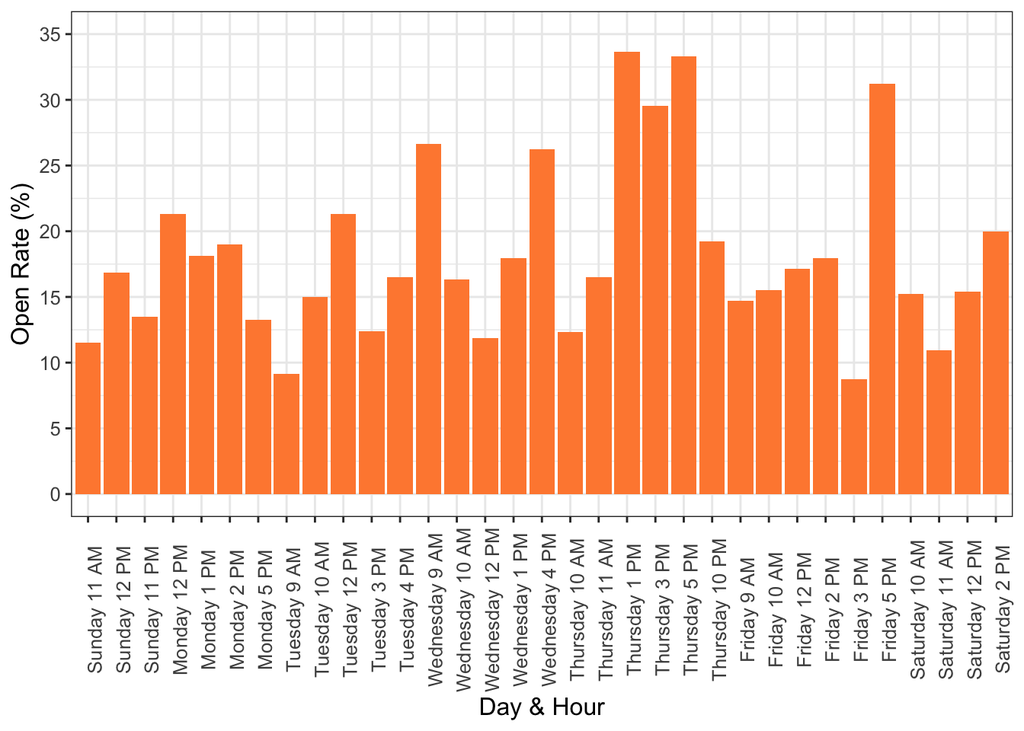

The mean open rate percent for emails sent on Thursday between 1PM and 5PM and Friday at 5PM were the highest. The following paragraphs outline the results from statistical tests for whether there is a difference between open rates across days of the week.

The best linear regression model that characterizes open rates utilizes the number of recipients, the number of emails sent that day, and the month of year as parameters. Testing of different models found that these were the only statistically significant variables that affect open rate percent.

However to assess the influence of day of week on open rate it has to be added to the model, despite no statistical basis. When we account for all of the other variables in the model (recipients, frequency, etc.), there is no statistical evidence that the day and hour combination influences open rate.

```
## Anova Table (Type II tests)
##
## Response: open_rate_pct
##            Sum Sq Df F value  Pr(>F)
## Recipients 115.36  1  5.9040 0.02332 *
## day_freq    15.09  1  0.7721 0.38867
## month_f    206.46  5  2.1132 0.10023
## day_hour   745.49 32  1.1922 0.33468
## Residuals  449.42 23
## ---
## Signif. codes:  0 '***' 0.001 '**' 0.01 '*' 0.05 '.' 0.1 ' ' 1
```

These results indicate that there was no statistical evidence that open rate percent was affected by the day of the week and hour of day combination. However, because the data collected is a census, thus representing all of the emails sent, we are not dealing with a sample and can make conclusions based on statistics easier to calculate, such as the mean.

#### Adjusted Open Rate

The figures and analysis below use the adjusted open rate percent as the metric. Adjusted open rate is a weighted open rate proportional to the number of recipients.

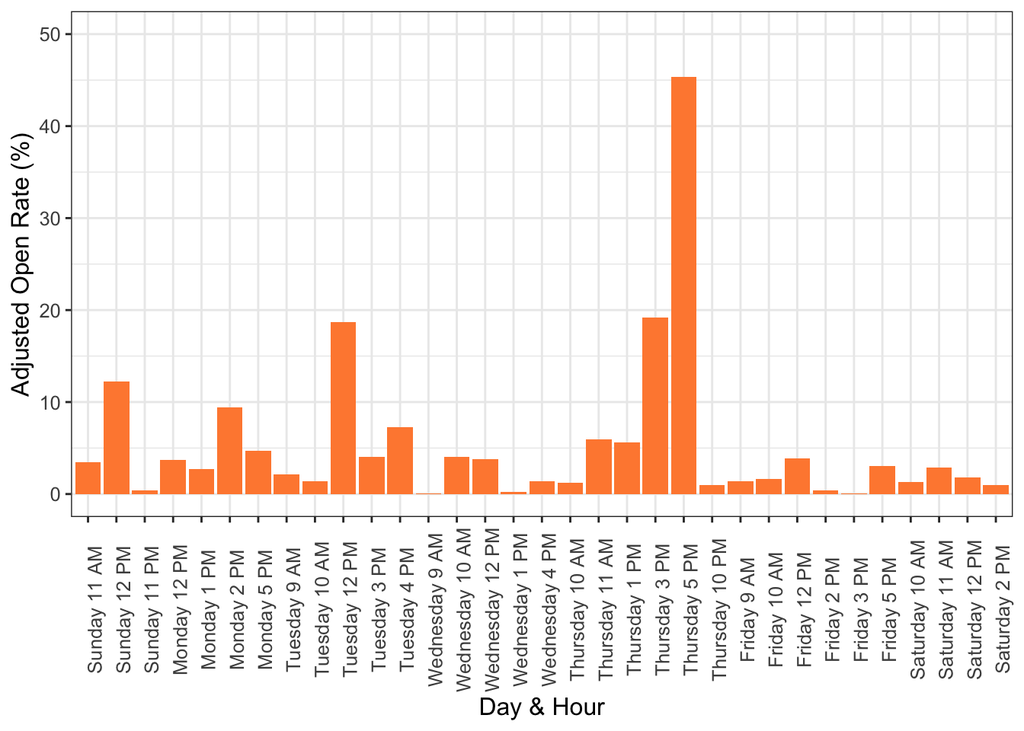

The mean open rate percent for emails sent on Thursdays at 5PM was the highest. The following paragraphs outline the results from statistical tests for whether there is a difference between open rates across days of the week.

The best linear regression model that characterizes open rates utilizes the number of recipients, the number of emails sent that week, and the month of year as parameters. Testing of different models found that these were the only statistically significant variables that affect open rate percent.

```
## Anova Table (Type II tests)
##
## Response: open_rate_adj
##             Sum Sq Df F value   Pr(>F)
## Recipients  117.74  1 12.3423 0.001867 **
## week_freq    18.21  1  1.9088 0.180371
## month_f      70.83  5  1.4849 0.233255
## day_hour   1035.81 32  3.3932 0.001681 **
## Residuals   219.41 23
## ---
## Signif. codes:  0 '***' 0.001 '**' 0.01 '*' 0.05 '.' 0.1 ' ' 1
```

#### Conclusion

Thursday at 5PM is the best hour of the day to send emails, with an expected average open rate of 33% and average adjusted open rate of 45%. This indicates that even when accounting for recipients, this day and time results in the highest open rates.

Thursdays between 1PM - 5PM are also good times, as well as Friday at 5PM, and Wednesday at 4PM. Also noteworthy is that sending emails before 1PM seems to decrease open rates.

## Question 3

The third question was how the frequency of emails influences open rates? First, the relationship between open rate (raw and adjusted) and frequency of emails sent in a month, week, or day are shown. Following is interpretation and more statistical assessments.

### Monthly Frequency

The figures below illustrate the relationship between open rate (raw and adjusted, note y axis label), across different frequencies of monthly emails. The bars indicate the 95% CI around the mean. This means that if we repeated collecting email data, we would expect the true mean open rate of emails would fall within this range 95% of samples. Further Interpretation of open rate and adjusted open rate’s relationship with monthly frequency is below.

#### Raw Open Rate

The figures and analysis below use the original open rate percent as the metric. Recipients are accounted for in the statistical analysis.

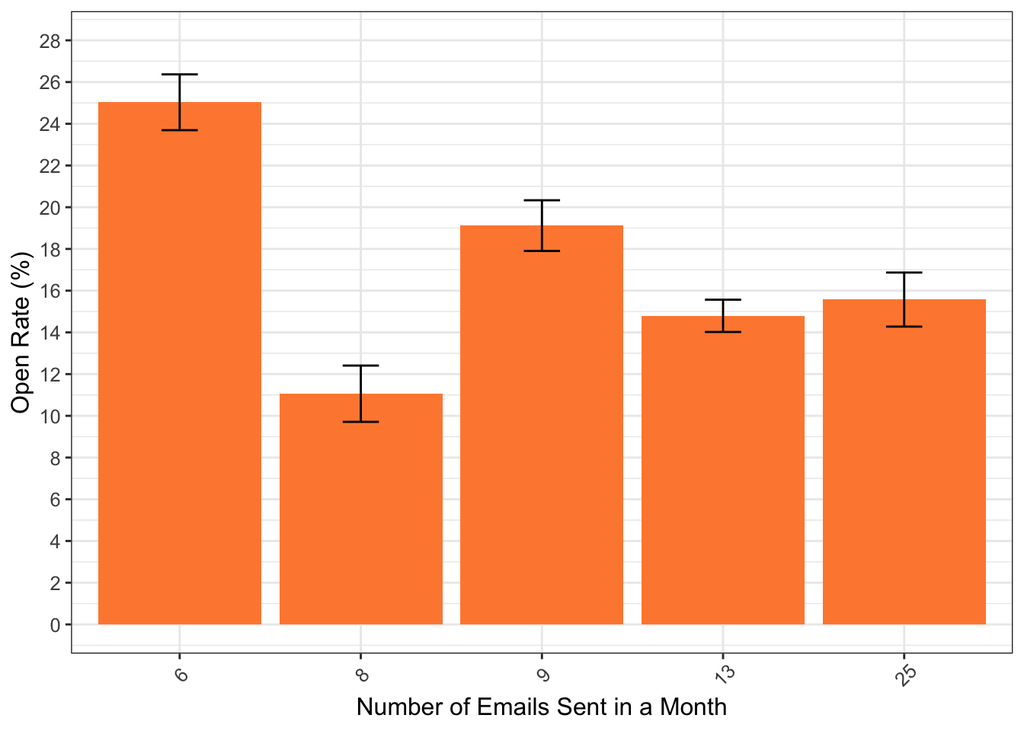

The mean open rate percent was highest with 6 emails sent per month. In months where more than 9 emails were sent the open rate declined.

The best linear regression model that characterizes open rates utilizes the number of recipients, the number of emails sent that day, and the month of year as parameters. Testing of different models found that these were the only statistically significant variables that affect open rate percent.

However to assess the influence of day of week on open rate it has to be added to the model, despite no statistical basis. When we account for all of the other variables in the model (recipients, frequency, etc.), there is no statistical evidence that the day of the week an email is sent influences open rate.

```
## Anova Table (Type II tests)
##
## Response: open_rate_pct
##             Sum Sq Df F value    Pr(>F)
## Recipients  205.03  1  9.6090  0.003028 **
## day_freq     74.57  1  3.4948  0.066793 .
## month_f     955.66  4 11.1969 9.602e-07 ***
## month_freq          0
## Residuals  1194.91 56
## ---
## Signif. codes:  0 '***' 0.001 '**' 0.01 '*' 0.05 '.' 0.1 ' ' 1
```

These results indicate that there was no statistical evidence that open rate percent was affected by the frequency of emails sent in a month. However, because the data collected is a census, thus representing all of the emails sent, we are not dealing with a sample and can make conclusions based on statistics easier to calculate, such as the mean.

#### Adjusted Open Rate

The figures and analysis below use the adjusted open rate percent as the metric.

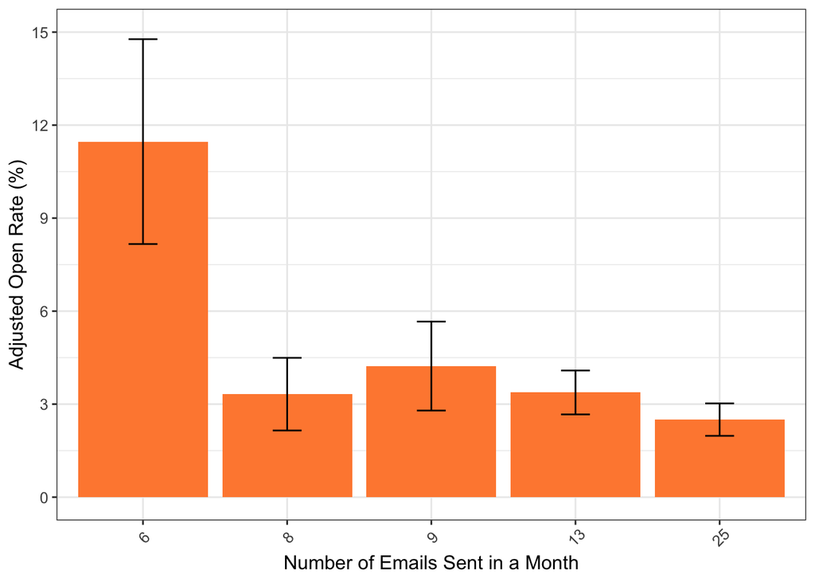

The mean open rate percent was highest with 6 emails sent per month. In months where more than 9 emails were sent the open rate declined.

The best linear regression model that characterizes open rates utilizes the number of recipients, the number of emails sent that week, and the month of year as parameters. Testing of different models found that these were the only statistically significant variables that affect open rate percent.

However to assess the influence of day of week on open rate it has to be added to the model, despite no statistical basis. When we account for all of the other variables in the model (recipients, frequency, etc.), there is no statistical evidence that the day of the week an email is sent influences open rate.

```
## Anova Table (Type II tests)
##
## Response: open_rate_adj
##             Sum Sq Df F value    Pr(>F)
## Recipients 1134.57  1 50.6154 2.239e-09 ***
## week_freq    89.23  1  3.9805 0.0509043 .
## month_f     504.37  4  5.6252 0.0007051 ***
## month_freq          0
## Residuals  1255.27 56
## ---
## Signif. codes:  0 '***' 0.001 '**' 0.01 '*' 0.05 '.' 0.1 ' ' 1
```

The same trend as the raw data was seen with the adjusted open rate. Less emails per month results in higher open rates.

### Weekly Frequency

The figures below illustrate the relationship between open rate (raw and adjusted, note y axis label), across different frequencies of weekly emails. The bars indicate the 95% CI around the mean. This means that if we repeated collecting email data, we would expect the true mean open rate of emails would fall within this range 95% of samples. Further Interpretation of open rate and adjusted open rate’s relationship with weekly frequency is below.

#### Raw Open Rate

The figures and analysis below use the original open rate percent as the metric. Recipients are accounted for in the statistical analysis.

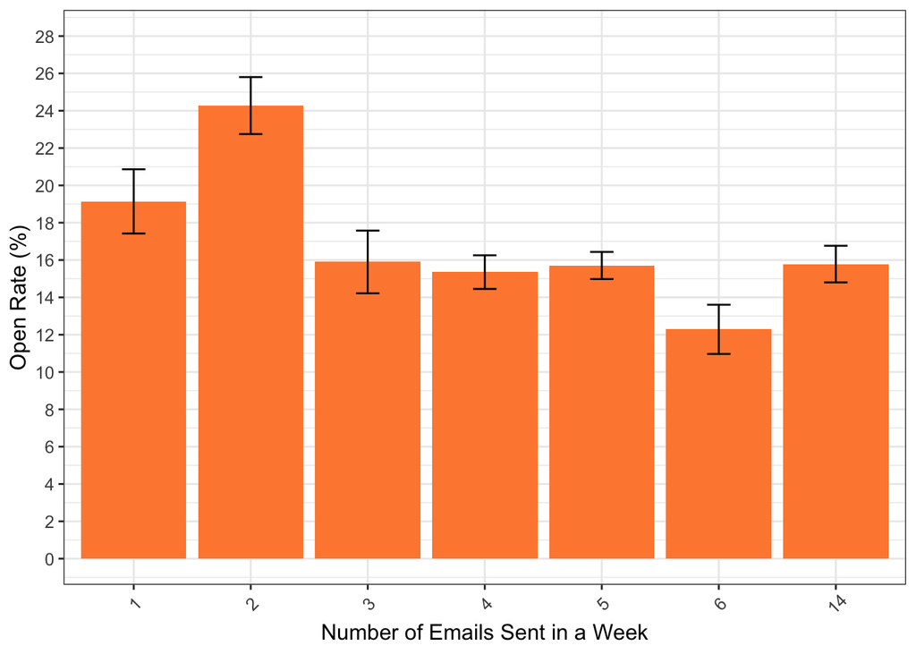

The mean open rate percent was highest with 2 emails sent per week. In weeks where more than 2 emails were sent the open rate declined.

However to assess the influence of day of week on open rate it has to be added to the model, despite no statistical basis. When we account for all of the other variables in the model (recipients, frequency, etc.), there is no statistical evidence that the day of the week an email is sent influences open rate.

```
## Anova Table (Type II tests)
##
## Response: open_rate_pct
##             Sum Sq Df F value   Pr(>F)
## Recipients  151.50  1  7.0033  0.01059 *
## day_freq     70.20  1  3.2451  0.07712 .
## month_f    1009.13  5  9.3300 1.77e-06 ***
## week_freq     5.15  1  0.2381  0.62753
## Residuals  1189.76 55
## ---
## Signif. codes:  0 '***' 0.001 '**' 0.01 '*' 0.05 '.' 0.1 ' ' 1
```

These results indicate that there was no statistical evidence that open rate percent was affected by the frequency of emails sent in a week. However, because the data collected is a census, thus representing all of the emails sent, we are not dealing with a sample and can make conclusions based on statistics easier to calculate, such as the mean.

The average open rate was 24% when 2 emails were sent per week. The average open rate was 19% when 1 emails were sent in a week and was 12-15% for more than 2 emails sent in a week.

#### Adjusted Open Rate

The figures and analysis below use the adjusted open rate percent as the metric.

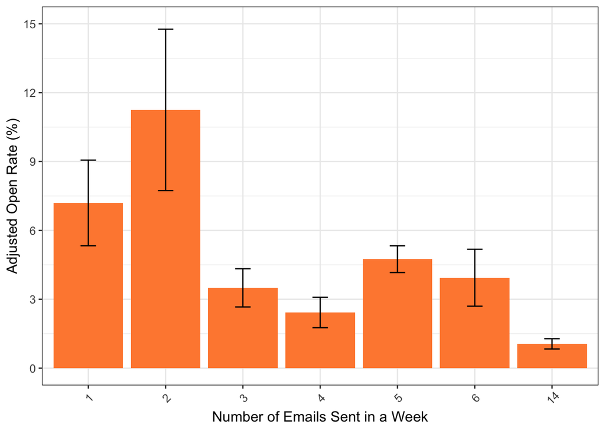

The mean open rate percent was highest with 2 emails sent per week. In weeks where more than 2 emails were sent the open rate declined.

However to assess the influence of day of week on open rate it has to be added to the model, despite no statistical basis. When we account for all of the other variables in the model (recipients, frequency, etc.), there is no statistical evidence that the day of the week an email is sent influences open rate.

```
## Anova Table (Type II tests)
##
## Response: open_rate_adj
##             Sum Sq Df F value    Pr(>F)
## Recipients 1134.57  1 50.6154 2.239e-09 ***
## week_freq    89.23  1  3.9805 0.0509043 .
## month_f     709.59  5  6.3312 0.0001006 ***
## Residuals  1255.27 56
## ---
## Signif. codes:  0 '***' 0.001 '**' 0.01 '*' 0.05 '.' 0.1 ' ' 1
```

### Daily Frequency

The figures below illustrate the relationship between open rate (raw and adjusted, note y axis label), across different frequencies of daily emails. The bars indicate the 95% CI around the mean. This means that if we repeated collecting email data, we would expect the true mean open rate of emails would fall within this range 95% of samples. Further Interpretation of open rate and adjusted open rate’s relationship with daily frequency is below.

#### Raw Open Rate

The figures and analysis below use the original open rate percent as the metric. Recipients are accounted for in the statistical analysis.

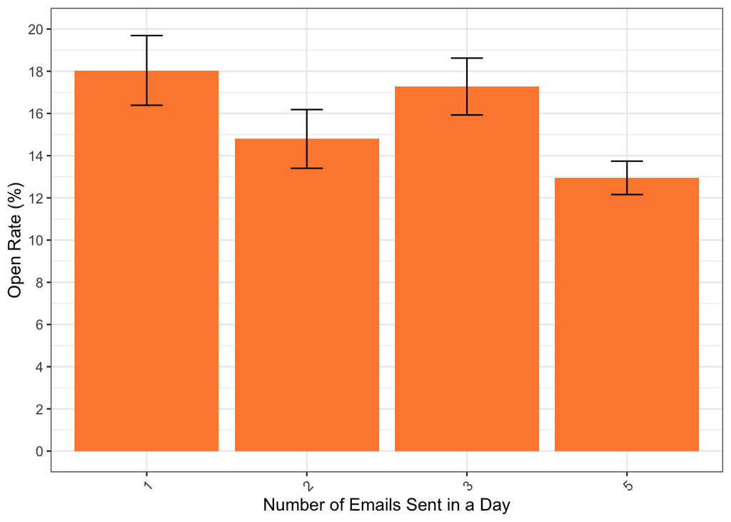

The mean open rate percent was highest with 1 emails sent per day. Sending 5 emails a day resulted in the lowest average open rates.

However to assess the influence of day of day on open rate it has to be added to the model, despite no statistical basis. When we account for all of the other variables in the model (recipients, frequency, etc.), there is no statistical evidence that the day of the day an email is sent influences open rate.

```
## Anova Table (Type II tests)
##
## Response: open_rate_pct
##             Sum Sq Df F value    Pr(>F)
## Recipients  205.03  1  9.6090  0.003028 **
## day_freq     74.57  1  3.4948  0.066793 .
## month_f    1076.53  5 10.0904 6.349e-07 ***
## Residuals  1194.91 56
## ---
## Signif. codes:  0 '***' 0.001 '**' 0.01 '*' 0.05 '.' 0.1 ' ' 1
```

The average open rate was 18% when 1 email were sent per day. The average open rate was 17% when 3 emails were sent in a day, 14% when 2 emails were sent in a day and 12% when 5 emails were sent in a day.

#### Adjusted Open Rate

The figures and analysis below use the adjusted open rate percent as the metric.

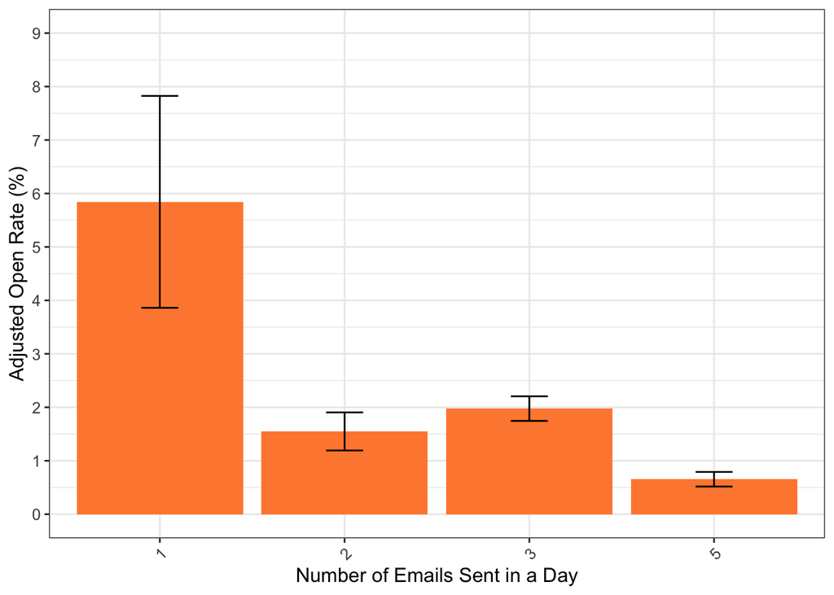

The best linear regression model that characterizes open rates utilizes the number of recipients, and the interaction of month and weekday as parameters. Testing of different models found that these were the only statistically significant variables that affect open rate percent.

However to assess the influence of day of day on open rate it has to be added to the model, despite no statistical basis. When we account for all of the other variables in the model (recipients, frequency, etc.), there is no statistical evidence that the day of the day an email is sent influences open rate.

```
## Anova Table (Type II tests)
##
## Response: open_rate_adj
##                   Sum Sq Df F value    Pr(>F)
## Recipients         76.42  1 27.4838 1.293e-05 ***
## month_f           554.93  5 39.9165 3.877e-12 ***
## weekday_f         274.51  6 16.4548 3.657e-08 ***
## day_freq           10.84  1  3.8988   0.05791 .
## month_f:weekday_f 979.54 21 16.7761 4.852e-11 ***
## Residuals          80.63 29
## ---
## Signif. codes:  0 '***' 0.001 '**' 0.01 '*' 0.05 '.' 0.1 ' ' 1
```

### Conclusion

Sending more emails in a month, week, and day all lower average open rates. The frequency of emails per month, week, and day follow with the corresponding open rate. The average open rate was 25% when 6 emails were sent per month, the average open rate was 24% when 2 emails were sent per week, and the average open rate was 18% when 1 email were sent per day.

# Instagram

## Summary

- What day of the week and time of day have the highest engagement rate
- What combination of day and time had highest engagement rate?
- Do graphics or photos have higher engagement rates?

# Facebook

## Summary

- What day of the week and time of day have the highest engagement rate?
- What combination of day and time had highest engagement rate?
- Do graphics or photos have higher engagement rates?

# TikTok

## Summary

- What day of the week and time of day have the highest likes per plays?
- What combination of day and time had highest likes per plays?
- How does posting frequency influence likes per plays?